[output not shown]

[output not shown]

### 5. Jupyter cell코드 뽑아오기.

**Jupyter Notebook** 1개를 포스팅하려면 최소한 2개의 파일을 만들어야 해요.  
뭘 자꾸 만들라고 하니 무섭지만 그래도 이쁘게 포스팅을 하고 원하는 바를 이루고 싶다면 조금만 참고 하면 되요 그리고 그리 어렵지도 않아요. 첫번째는 `<iframe>`으로 들어갈 **Jupyter Notebook** 내용을 담은 파일이고 두번째는 `<iframe>`태그를 넣은 `.md`포스트에요.

위에서 알려 드린바와 같이

```
jupyter nbconvert --to html --template classic --no-prompt ./파일명1.ipynb --ouput 파일명2.html
```

코드를 실행하면 html파일 하나가 생성되는데 **jupyter**셀 코드는 아래서 처럼 `<body>`태그로 시작해서 끝까지에요.

```
<div tabindex="-1" id="notebook" class="border-box-sizing">
    <div class="container" id="notebook-container">

<div class="cell border-box-sizing text_cell rendered"><div class="inner_cell">
<div class="text_cell_render border-box-sizing rendered_html">
<h1 id="Jupyter-Notebook">Jupyter Notebook<a class="anchor-link" href="#Jupyter-Notebook">&#182;</a></h1>
</div>
</div>
</div>
<div class="cell border-box-sizing code_cell rendered">
<div class="input">

<div class="inner_cell">
    <div class="input_area">
<div class=" highlight hl-ipython3"><pre><span></span><span class="kn">import</span> <span class="nn">pandas</span> <span class="k">as</span> <span class="nn">pd</span>
<span class="kn">import</span> <span class="nn">matplotlib.pyplot</span> <span class="k">as</span> <span class="nn">plt</span>
</pre></div>

    </div>
</div>
</div>
```

### 6. 포스팅하기

`/assets/iframes/jupyter-notebooks/파일명2.html`경로로 폴더와 파일을 생성한뒤 젤 윗줄에

```
---
layout: jupyter-notebook-v4.6.3
---
```

으로 YAML Front Matter양식 헤더를 추가하고 5번에서 뽑아온 **jupyter**셀코드를  
copy & paste 해주면 준비는 끝났습니다.  
이제 마지막으로 포스팅하던 `_posts`폴더에 늘 포스팅하듯 `.md`파일을 생성해주고  
`<iframe id="f1" name="f1" src="/assets/iframes/jupyter-notebooks/2021-01-07-simple/">Jupyter Notebook</iframe>`을 붙여넣기 해주면 포스팅이 완료됩니다.

### 7. 이미지는 파일에 임베드 하지 말자.

맨 위에 nbconvert 변환 할 때 변환 파일안에 이미지 바이너리 테이터가 통째로 박혀 있어요. 하지만 이미지는 기본적으로 용량이 크므로 Git Repository용량에 부담이 되므로 다른이름으로 저장한 다음 구글클라우드 같은 곳에 넣어두고 가져오는걸로 해요. **Jupyter**코드셀 마지막 부분에 `<img scr="...">`이런 부분이 있는데 이걸 지우고 다른곳에 올린 주소를 `...`부분에 넣으면 되요. 저는 아직 하진 않았고 나중에 시각화자료가 많아지거나 데이터가 큰 시각화자료라면 해보겠어요.

### 8. 끝으로

이번 포스팅은 저도 잘 모르는 분야를 다른분 포스팅을 보고 옮겨적는 수준이라 아마 이해가 안되는 부분도 많을 거에요 하지만 그래도 저는 성공을 했고 그 걸 남기고 싶어서 포스팅을 하고 있는거에요.  
제 포스팅을 보고도 이해가 되지 않거나 잘 모르겠으면 질문을 남겨 주시거나 [Sammy Beak](https://seungwubaek.github.io/blog/tips/jupyter_to_html/#page-title)여기를 보면 충분히 여러분들도 해결 할 수 있을 거라 생각해요.  
이 포스팅을 생각한지는 정말 2주? 정도 지났지만 이제야 해결한것 같아서 속이 정말 후련하고 시원해요. 앞서 말했지만 끝으로 [Sammy Beak](https://seungwubaek.github.io/blog/tips/jupyter_to_html/#page-title)님 너무 감사드립니다.

#### 9. 간단 예제

```python
import pandas as pd
import matplotlib.pyplot as plt
```

```python
columns = ['col1', 'col2', 'col3', 'col4']
data = [[1,2,3,4],[5,6,7,8],[9,10,11,12]]
```

```python
df = pd.DataFrame(data, columns = columns)
```

```python
df
```

|  | col1 | col2 | col3 | col4 |
| --- | --- | --- | --- | --- |
| 0 | 1 | 2 | 3 | 4 |
| 1 | 5 | 6 | 7 | 8 |
| 2 | 9 | 10 | 11 | 12 |

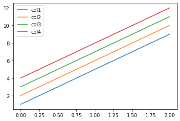

```python
plt.plot(df)
plt.legend(df.columns)
plt.show()
```